# IMT 573: Lab 7 - Multiple Regression

Madhusmita Oke

# Setup

Do whatever setup you do here, such as loading libraries

```r
# Load standard libraries
library("tidyverse")
```

# 1 Descriptive analysis

## 1.1 Load the data and perform basic sanity checks. How many diamonds do we have?

```r
df_diamonds <- read.delim("/Users/madhusmitaoke/MSIM-Academic/DataScience/IMT573-DSI/data/diamonds.csv.bz2")

dim(df_diamonds)
```

```
## [1] 53940    10
```

```r
names(df_diamonds)
```

```
##  [1] "carat"   "cut"     "color"   "clarity" "depth"   "table"   "price"
##  [8] "x"       "y"       "z"
```

```r
any(is.na(diamonds))
```

```
## [1] FALSE
```

```r
head(diamonds, 4)
```

```
## # A tibble: 4 × 10
##   carat cut     color clarity depth table price     x     y     z
##   <dbl> <ord>   <ord> <ord>   <dbl> <dbl> <int> <dbl> <dbl> <dbl>
## 1  0.23 Ideal   E     SI2      61.5    55   326  3.95  3.98  2.43
## 2  0.21 Premium E     SI1      59.8    61   326  3.89  3.84  2.31
## 3  0.23 Good    E     VS1      56.9    65   327  4.05  4.07  2.31
## 4  0.29 Premium I     VS2      62.4    58   334  4.2   4.23  2.63
```

There are 53940 observations with 10 features such as cut,carat, price etc No missing values in the data

## 1.2 Inspect the variable cut. What kind of different cuts are there? How frequent are those? Which one is the most common and which one is the least common?

```r
unique(df_diamonds$cut)
```

```
## [1] "Ideal"     "Premium"   "Good"      "Very Good" "Fair"
```

```r
df_cut_counts <- table(df_diamonds$cut)
df_cut_counts
```

```
##
##      Fair      Good     Ideal   Premium Very Good
##      1610      4906     21551     13791     12082
```

Different cuts are Fair, Good, Ideal, Premium and Very Good. Least common is Fair cut and most common is Ideal Cut.

# 2 Regression analysis

## 2.1 Include two variables: weight of diamonds (carat) and shape (cut).

```r
m <- lm(price ~ carat + cut ,data= df_diamonds )
summary(m)
```

```
##
## Call:
## lm(formula = price ~ carat + cut, data = df_diamonds)
##
## Residuals:
##      Min       1Q   Median       3Q      Max
## -17540.7   -791.6    -37.6    522.1  12721.4
##
## Coefficients:
##              Estimate Std. Error t value Pr(>|t|)
## (Intercept)  -3875.47      40.41  -95.91   <2e-16 ***
## carat         7871.08      13.98  563.04   <2e-16 ***
## cutGood       1120.33      43.50   25.75   <2e-16 ***
## cutIdeal      1800.92      39.34   45.77   <2e-16 ***
## cutPremium    1439.08      39.87   36.10   <2e-16 ***
## cutVery Good  1510.14      40.24   37.53   <2e-16 ***
## ---
## Signif. codes:  0 '***' 0.001 '**' 0.01 '*' 0.05 '.' 0.1 ' ' 1
##
## Residual standard error: 1511 on 53934 degrees of freedom
## Multiple R-squared:  0.8565, Adjusted R-squared:  0.8565
## F-statistic: 6.437e+04 on 5 and 53934 DF,  p-value: < 2.2e-16
```

## 2.2 What is the reference category for cut?

The reference category for cut is ‘Fair’

## 2.3 Interpret the following coefficients:

### 2.3.a What is “carat” ?

The value of “carat” is 7871.08 is coefficient beta1 indicating 1 unit increase in carat leads to 7871.08 units increase in price when keeping the “cut” constant.

### 2.3.b What is “cutIdeal” (correct value should be 1800)?

The coefficient for “cutIdeal” is 1800.92 indicating that 1 unit increase in ‘ideal’ cut keeping the carat constant leads to 1800.92 units increase in price. The price increase unit is in comparison to baseline which is ‘cutFair’ (denoted by intercept line price -3875.47)

### 2.3.c. How much more expensive are ideal-cut diamonds compared to very good-cut diamonds (in average) of similar weight?

The difference between coefficients associated with ‘ideal cut’ and ‘very good cut’ will determine the price difference for two categories (on average) keeping the carat (weight) constant

```r
1800.92 - 1510.14
```

```
## [1] 290.78
```

Ideal cut is more expensive by 290.78 price units as compared to very good cut diamonds (keeping carat constant)

### 2.3.d. What would be the (average) price for 1ct premium cut diamond?

Price = b0 + b1 * carat + b2 * cutPremium

This will give price of 1 carat premium cut where cutPremium =1 , carat =1 and other coeffients are substituted as:

Price = -3875.47 + (7871.08) * (1) + (1439.08) * (1)

```r
-3875.47 + (7871.08) * (1) + (1439.08) * (1)
```

```
## [1] 5434.69
```

Price (Avg) of 1 carat premium cut diamond is 5434.69 units

# 3 Challenge

## 3.1 Plot the “price” versus “mass” and add the regression line to it.

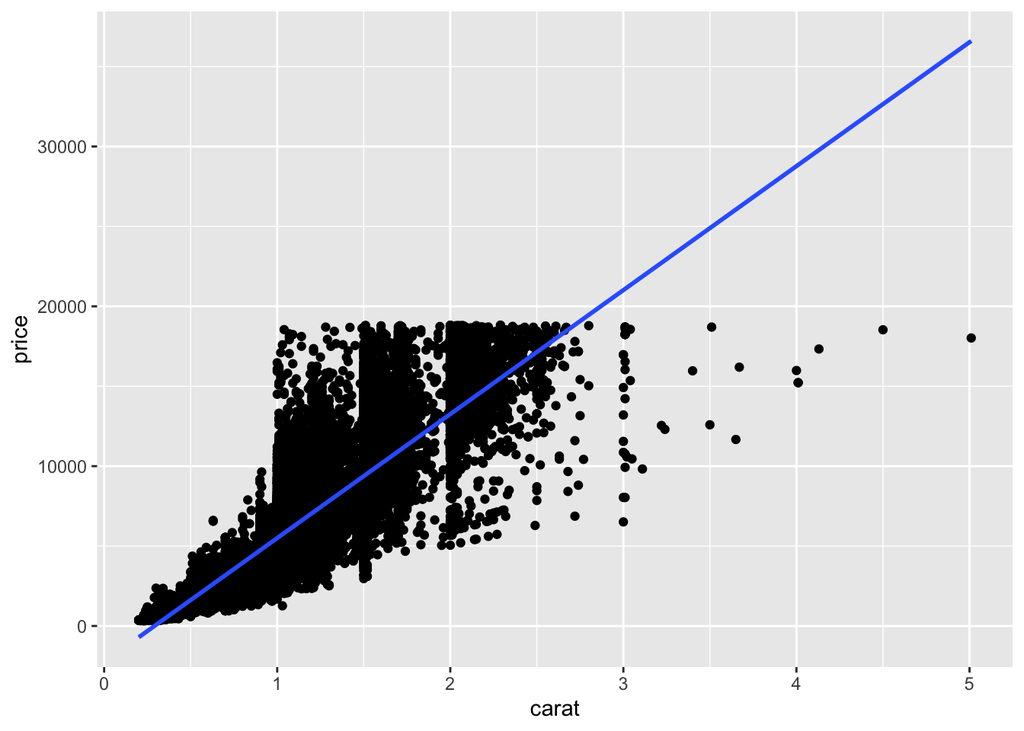

```r
ggplot(df_diamonds ,aes(carat, price) )+ geom_point() + geom_smooth(method = "lm", se=FALSE)
```

## 3.2 Experiment with log scale for a) “price”, b) “carat”, c) both. In which plot do the two variables look most linearly realted, i.e., the relationship looks like a line?

**Price with log scale**

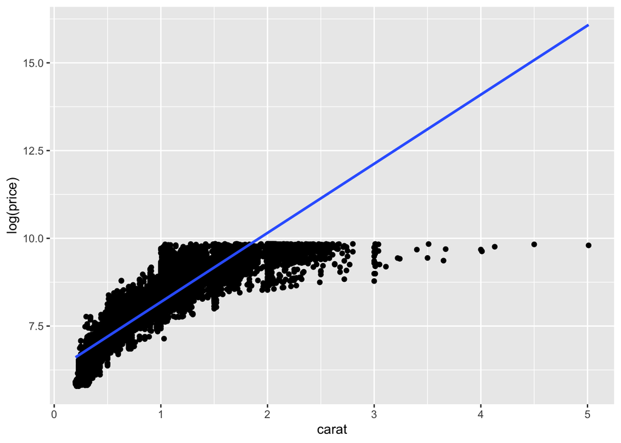

```r
ggplot(df_diamonds, aes(carat, log(price)) )+ geom_point() + geom_smooth(method = "lm", se=FALSE)
```

**Carat with log scale**

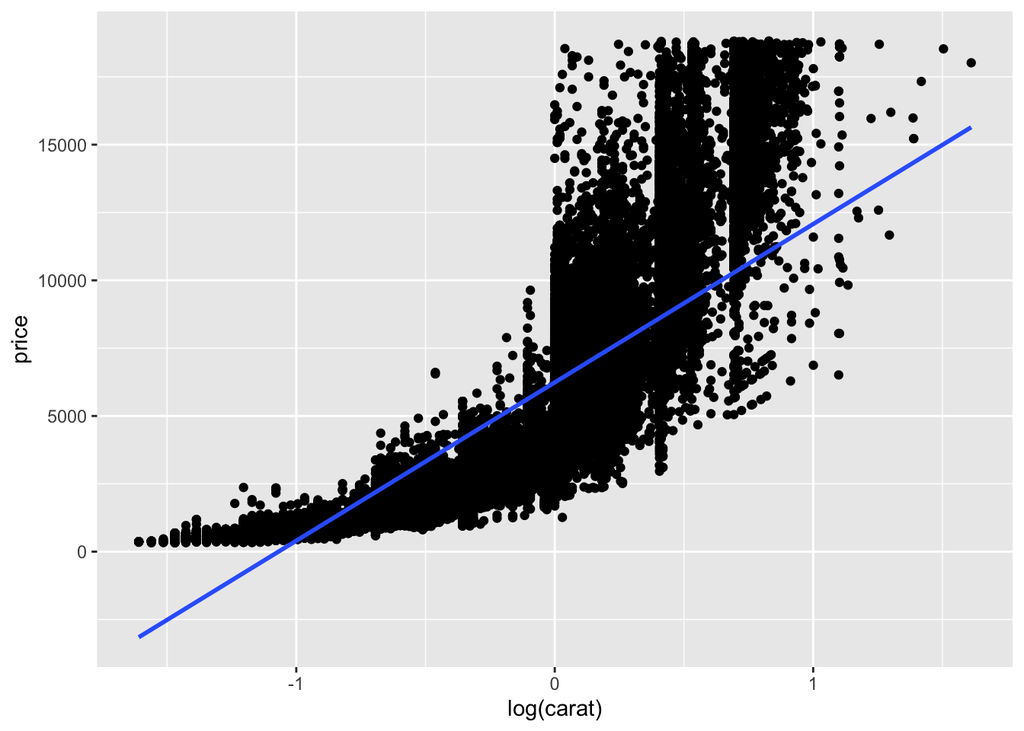

```r
ggplot(df_diamonds, aes(log(carat), price) )+ geom_point() + geom_smooth(method = "lm", se=FALSE)
```

**Both price and carat in log scale**

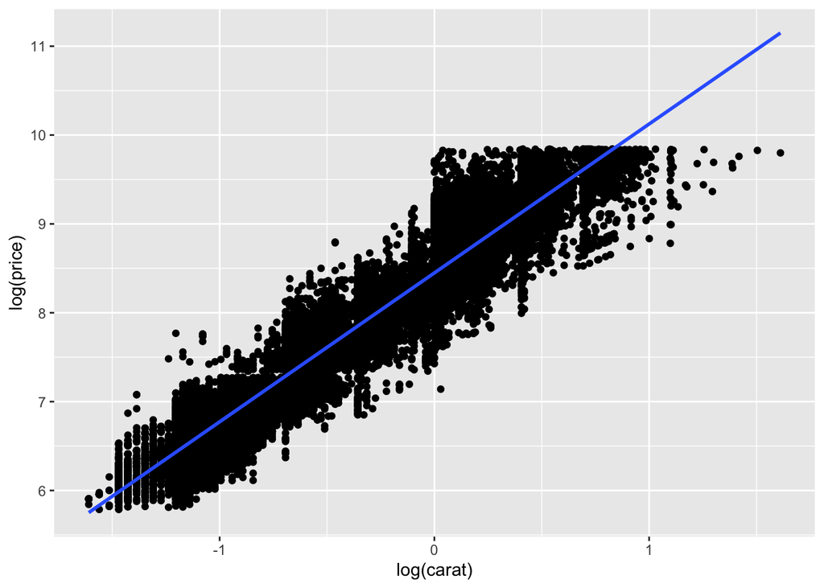

```r
ggplot(df_diamonds, aes(log(carat), log(price)) )+ geom_point() + geom_smooth(method = "lm", se=FALSE)
```

In the third plot where both price and carat are in log scale- the two variables mostly look linearly related!

## 3.3 Add the corresponding log-transform to your model. You can run log-transformed models just like lm(log(price) ∼ log(carat))

```r
m2 <- lm(log(price) ~ log(carat) ,data= df_diamonds )
summary(m2)
```

```
##
## Call:
## lm(formula = log(price) ~ log(carat), data = df_diamonds)
##
## Residuals:
##      Min       1Q   Median       3Q      Max
## -1.50833 -0.16951 -0.00591  0.16637  1.33793
##
## Coefficients:
##             Estimate Std. Error t value Pr(>|t|)
## (Intercept) 8.448661   0.001365  6190.9   <2e-16 ***
## log(carat)  1.675817   0.001934   866.6   <2e-16 ***
## ---
## Signif. codes:  0 '***' 0.001 '**' 0.01 '*' 0.05 '.' 0.1 ' ' 1
##
## Residual standard error: 0.2627 on 53938 degrees of freedom
## Multiple R-squared:  0.933,  Adjusted R-squared:  0.933
## F-statistic: 7.51e+05 on 1 and 53938 DF,  p-value: < 2.2e-16
```

looking at the p-value (<<0.05) log(carat) is statistically significant

## 3.4. Add “cut” to this model and interpret the coefficients.

```r
m3 <- lm(log(price) ~ log(carat)+ cut ,data= df_diamonds )
summary(m3)
```

```
##
## Call:
## lm(formula = log(price) ~ log(carat) + cut, data = df_diamonds)
##
## Residuals:
##      Min       1Q   Median       3Q      Max
## -1.52247 -0.16484 -0.00587  0.16087  1.38115
##
## Coefficients:
##              Estimate Std. Error t value Pr(>|t|)
## (Intercept)  8.200125   0.006343 1292.69   <2e-16 ***
## log(carat)   1.695771   0.001910  887.68   <2e-16 ***
## cutGood      0.163245   0.007324   22.29   <2e-16 ***
## cutIdeal     0.317212   0.006632   47.83   <2e-16 ***
## cutPremium   0.238217   0.006716   35.47   <2e-16 ***
## cutVery Good 0.240753   0.006779   35.52   <2e-16 ***
## ---
## Signif. codes:  0 '***' 0.001 '**' 0.01 '*' 0.05 '.' 0.1 ' ' 1
##
## Residual standard error: 0.2545 on 53934 degrees of freedom
## Multiple R-squared:  0.9371, Adjusted R-squared:  0.9371
## F-statistic: 1.607e+05 on 5 and 53934 DF,  p-value: < 2.2e-16
```